# Wisconsin Breast Cancer Dataset : Predicting Diagnosis

- Classification: k-Nearest Neighbors and Logistic Regresion

About the dataset: The data includes diagnosis of the tumor with *M* meaning cancer (malignant) and *B* no cancer (benign), and 10 features, describing physical properties of cell nuclei from biopsy samples. Each feature is represented three times, once for mean, once for standard error, and once for the worst values.

```python
# importing libraries

import pandas as pd
import numpy as np
import matplotlib.pyplot as plt
from sklearn.model_selection import train_test_split
from sklearn.linear_model import LinearRegression, Ridge, Lasso, LogisticRegression
```

```python
import seaborn as sns
from sklearn.neighbors import KNeighborsClassifier
from matplotlib.colors import ListedColormap
from sklearn.preprocessing import MinMaxScaler
from sklearn import metrics
```

```python
from sklearn.metrics import accuracy_score,precision_score,recall_score,f1_score, confusion_matrix,roc_curve, auc
```

```python
# reading the dataset

df = pd.read_csv("wdbc.csv.bz2")
df.head()
```

|  | id | diagnosis | radius.mean | texture.mean | perimeter.mean | area.mean | smoothness.mean | compactness.mean | concavity.mean | concpoints.mean | ... | radius.worst | texture.worst | perimeter.worst | area.worst | smoothness.worst | compactness.worst | concavity.worst | concpoints.worst | symmetry.worst | fracdim.worst |
| --- | --- | --- | --- | --- | --- | --- | --- | --- | --- | --- | --- | --- | --- | --- | --- | --- | --- | --- | --- | --- | --- |
| 0 | 842302 | M | 17.99 | 10.38 | 122.80 | 1001.0 | 0.11840 | 0.27760 | 0.3001 | 0.14710 | ... | 25.38 | 17.33 | 184.60 | 2019.0 | 0.1622 | 0.6656 | 0.7119 | 0.2654 | 0.4601 | 0.11890 |
| 1 | 842517 | M | 20.57 | 17.77 | 132.90 | 1326.0 | 0.08474 | 0.07864 | 0.0869 | 0.07017 | ... | 24.99 | 23.41 | 158.80 | 1956.0 | 0.1238 | 0.1866 | 0.2416 | 0.1860 | 0.2750 | 0.08902 |
| 2 | 84300903 | M | 19.69 | 21.25 | 130.00 | 1203.0 | 0.10960 | 0.15990 | 0.1974 | 0.12790 | ... | 23.57 | 25.53 | 152.50 | 1709.0 | 0.1444 | 0.4245 | 0.4504 | 0.2430 | 0.3613 | 0.08758 |
| 3 | 84348301 | M | 11.42 | 20.38 | 77.58 | 386.1 | 0.14250 | 0.28390 | 0.2414 | 0.10520 | ... | 14.91 | 26.50 | 98.87 | 567.7 | 0.2098 | 0.8663 | 0.6869 | 0.2575 | 0.6638 | 0.17300 |
| 4 | 84358402 | M | 20.29 | 14.34 | 135.10 | 1297.0 | 0.10030 | 0.13280 | 0.1980 | 0.10430 | ... | 22.54 | 16.67 | 152.20 | 1575.0 | 0.1374 | 0.2050 | 0.4000 | 0.1625 | 0.2364 | 0.07678 |

5 rows × 32 columns

```python
# Mapping diagnosis values to 1 and 0

df = df.drop(['id'],axis = 1)
df['diagnosis'] = np.where(df.diagnosis=='M', 1,0)
df.head(7)
```

|  | diagnosis | radius.mean | texture.mean | perimeter.mean | area.mean | smoothness.mean | compactness.mean | concavity.mean | concpoints.mean | symmetry.mean | ... | radius.worst | texture.worst | perimeter.worst | area.worst | smoothness.worst | compactness.worst | concavity.worst | concpoints.worst | symmetry.worst | fracdim.worst |
| --- | --- | --- | --- | --- | --- | --- | --- | --- | --- | --- | --- | --- | --- | --- | --- | --- | --- | --- | --- | --- | --- |
| 0 | 1 | 17.99 | 10.38 | 122.80 | 1001.0 | 0.11840 | 0.27760 | 0.3001 | 0.14710 | 0.2419 | ... | 25.38 | 17.33 | 184.60 | 2019.0 | 0.1622 | 0.6656 | 0.7119 | 0.2654 | 0.4601 | 0.11890 |
| 1 | 1 | 20.57 | 17.77 | 132.90 | 1326.0 | 0.08474 | 0.07864 | 0.0869 | 0.07017 | 0.1812 | ... | 24.99 | 23.41 | 158.80 | 1956.0 | 0.1238 | 0.1866 | 0.2416 | 0.1860 | 0.2750 | 0.08902 |
| 2 | 1 | 19.69 | 21.25 | 130.00 | 1203.0 | 0.10960 | 0.15990 | 0.1974 | 0.12790 | 0.2069 | ... | 23.57 | 25.53 | 152.50 | 1709.0 | 0.1444 | 0.4245 | 0.4504 | 0.2430 | 0.3613 | 0.08758 |
| 3 | 1 | 11.42 | 20.38 | 77.58 | 386.1 | 0.14250 | 0.28390 | 0.2414 | 0.10520 | 0.2597 | ... | 14.91 | 26.50 | 98.87 | 567.7 | 0.2098 | 0.8663 | 0.6869 | 0.2575 | 0.6638 | 0.17300 |
| 4 | 1 | 20.29 | 14.34 | 135.10 | 1297.0 | 0.10030 | 0.13280 | 0.1980 | 0.10430 | 0.1809 | ... | 22.54 | 16.67 | 152.20 | 1575.0 | 0.1374 | 0.2050 | 0.4000 | 0.1625 | 0.2364 | 0.07678 |
| 5 | 1 | 12.45 | 15.70 | 82.57 | 477.1 | 0.12780 | 0.17000 | 0.1578 | 0.08089 | 0.2087 | ... | 15.47 | 23.75 | 103.40 | 741.6 | 0.1791 | 0.5249 | 0.5355 | 0.1741 | 0.3985 | 0.12440 |
| 6 | 1 | 18.25 | 19.98 | 119.60 | 1040.0 | 0.09463 | 0.10900 | 0.1127 | 0.07400 | 0.1794 | ... | 22.88 | 27.66 | 153.20 | 1606.0 | 0.1442 | 0.2576 | 0.3784 | 0.1932 | 0.3063 | 0.08368 |

7 rows × 31 columns

```python
df.columns
```

```
Index(['diagnosis', 'radius.mean', 'texture.mean', 'perimeter.mean',
       'area.mean', 'smoothness.mean', 'compactness.mean', 'concavity.mean',
       'concpoints.mean', 'symmetry.mean', 'fracdim.mean', 'radius.se',
       'texture.se', 'perimeter.se', 'area.se', 'smoothness.se',
       'compactness.se', 'concavity.se', 'concpoints.se', 'symmetry.se',
       'fracdim.se', 'radius.worst', 'texture.worst', 'perimeter.worst',
       'area.worst', 'smoothness.worst', 'compactness.worst',
       'concavity.worst', 'concpoints.worst', 'symmetry.worst',
       'fracdim.worst'],
      dtype='object')
```

Clculating summary statistics

```python
# Summary Statistics
# we can also use df.describe() to get the summary statistics but calculating it manually here

mean_df = df.mean().to_frame('Mean')                        # mean
range_df = (df.max() - df.min()).to_frame('Range')          # range
missings = df.isnull().sum().to_frame('Missings')           # Null values if any
summary = pd.concat([mean_df,range_df,missings],axis=1)
summary.head()
```

|  | Mean | Range | Missings |
| --- | --- | --- | --- |
| diagnosis | 0.372583 | 1.000 | 0 |
| radius.mean | 14.127292 | 21.129 | 0 |
| texture.mean | 19.289649 | 29.570 | 0 |
| perimeter.mean | 91.969033 | 144.710 | 0 |
| area.mean | 654.889104 | 2357.500 | 0 |

```python
# Correlation between diagnosis (target class) and corresponding fetaures
corr ={}                                       # creating a dictionary to store values

for i in df.columns:
    corr[i] = df['diagnosis'].corr(df[i])      # calculating the corr and then storing the correspondin values to the dictionary
```

```python
# Removing warning
# pd.options.mode.chained_assignment = None
```

```python
# adding correlation values to the summary dataframe

summary['Correlation'] = 0
for index,value in corr.items():
    summary.Correlation.loc[index] = value
```

```python
summary.head()
```

|  | Mean | Range | Missings | Correlation |
| --- | --- | --- | --- | --- |
| diagnosis | 0.372583 | 1.000 | 0 | 1.000000 |
| radius.mean | 14.127292 | 21.129 | 0 | 0.730029 |
| texture.mean | 19.289649 | 29.570 | 0 | 0.415185 |
| perimeter.mean | 91.969033 | 144.710 | 0 | 0.742636 |
| area.mean | 654.889104 | 2357.500 | 0 | 0.708984 |

### Graphical Exploration

```python
sns.set()        # sets to seaborn defaults
```

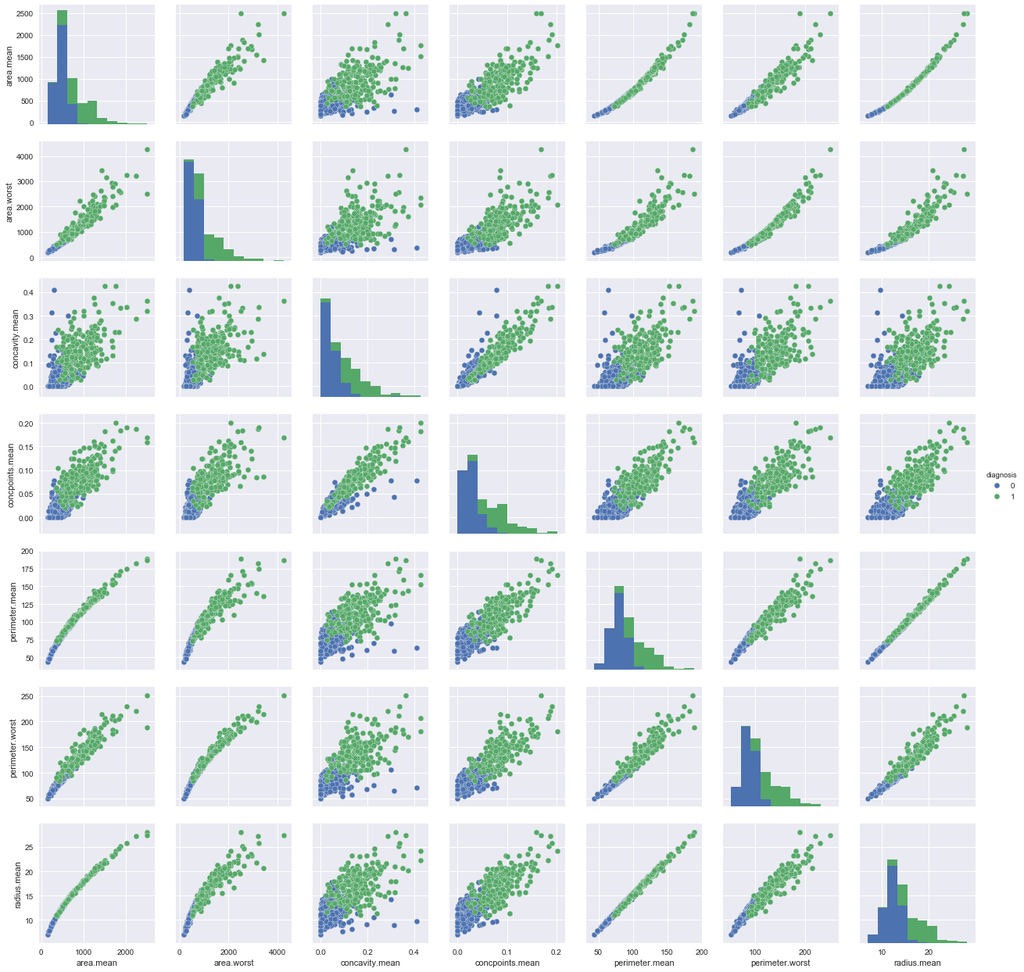

```python
# Checking how the target class Y (diagnosis) is distributed for some of the highly correlated features
graph = sns.pairplot(df, x_vars=['area.mean',"area.worst",'concavity.mean','concpoints.mean',
                               'perimeter.mean','perimeter.worst','radius.mean'],
                 y_vars=['area.mean',"area.worst",'concavity.mean','concpoints.mean',
                         'perimeter.mean','perimeter.worst','radius.mean'],hue="diagnosis")
```

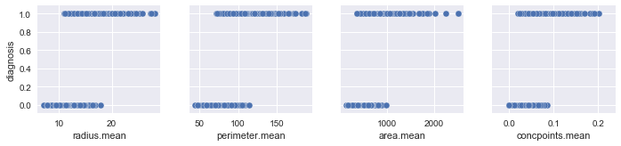

```python
# pairplots for diagnosis (target class) vs input features X, one at a time
sns.pairplot(df,y_vars=['diagnosis'],x_vars=['radius.mean','perimeter.mean','area.mean','concpoints.mean'])
```

# 2.Decision Boundary

```python
# Scaling the features
scaler = MinMaxScaler()
scaler.fit(df)
scaled_df = pd.DataFrame(scaler.transform(df), columns=df.columns)    # dataframe after scaling
scaled_df.head()
```

|  | diagnosis | radius.mean | texture.mean | perimeter.mean | area.mean | smoothness.mean | compactness.mean | concavity.mean | concpoints.mean | symmetry.mean | ... | radius.worst | texture.worst | perimeter.worst | area.worst | smoothness.worst | compactness.worst | concavity.worst | concpoints.worst | symmetry.worst | fracdim.worst |
| --- | --- | --- | --- | --- | --- | --- | --- | --- | --- | --- | --- | --- | --- | --- | --- | --- | --- | --- | --- | --- | --- |
| 0 | 1.0 | 0.521037 | 0.022658 | 0.545989 | 0.363733 | 0.593753 | 0.792037 | 0.703140 | 0.731113 | 0.686364 | ... | 0.620776 | 0.141525 | 0.668310 | 0.450698 | 0.601136 | 0.619292 | 0.568610 | 0.912027 | 0.598462 | 0.418864 |
| 1 | 1.0 | 0.643144 | 0.272574 | 0.615783 | 0.501591 | 0.289880 | 0.181768 | 0.203608 | 0.348757 | 0.379798 | ... | 0.606901 | 0.303571 | 0.539818 | 0.435214 | 0.347553 | 0.154563 | 0.192971 | 0.639175 | 0.233590 | 0.222878 |
| 2 | 1.0 | 0.601496 | 0.390260 | 0.595743 | 0.449417 | 0.514309 | 0.431017 | 0.462512 | 0.635686 | 0.509596 | ... | 0.556386 | 0.360075 | 0.508442 | 0.374508 | 0.483590 | 0.385375 | 0.359744 | 0.835052 | 0.403706 | 0.213433 |
| 3 | 1.0 | 0.210090 | 0.360839 | 0.233501 | 0.102906 | 0.811321 | 0.811361 | 0.565604 | 0.522863 | 0.776263 | ... | 0.248310 | 0.385928 | 0.241347 | 0.094008 | 0.915472 | 0.814012 | 0.548642 | 0.884880 | 1.000000 | 0.773711 |
| 4 | 1.0 | 0.629893 | 0.156578 | 0.630986 | 0.489290 | 0.430351 | 0.347893 | 0.463918 | 0.518390 | 0.378283 | ... | 0.519744 | 0.123934 | 0.506948 | 0.341575 | 0.437364 | 0.172415 | 0.319489 | 0.558419 | 0.157500 | 0.142595 |

5 rows × 31 columns

### 2.1 kNN Case

```python
# Selecting two features which have high correlation with the target (diagnosis)
X = scaled_df[['concpoints.mean','perimeter.mean']]
y = scaled_df['diagnosis']
```

```python
# kNN classifier with k=4
knn_clf = KNeighborsClassifier(n_neighbors=4)
knn_clf = knn_clf.fit(X,y)
```

```python
knn_clf
```

```
KNeighborsClassifier(algorithm='auto', leaf_size=30, metric='minkowski',
           metric_params=None, n_jobs=1, n_neighbors=4, p=2,
           weights='uniform')
```

```python
# function to create decision regions or grids

def decision_region(dataFrame,feature1,feature2):
    """
    Function to plot decision regions.
    Takes in the dataframe with two features a and b.
    Returns the grid for plotting decision boundary.
    """
    x_min,x_max = dataFrame[feature1].min() - 0.1, dataFrame[feature1].max() + 0.1
    y_min,y_max = dataFrame[feature2].min() - 0.1, dataFrame[feature2].max() + 0.1
    xx, yy = np.meshgrid(np.linspace(x_min,x_max,100),np.linspace(y_min,y_max,100))  #create a rectangular grid out of an array of x values and an array of y values.
    return xx,yy
```

```python
xx,yy = decision_region(X,'concpoints.mean','perimeter.mean')
```

```python
#xx.ravel()
#len(xx.ravel())
```

```python
# len(knn_clf.predict(np.c_[xx.ravel(),yy.ravel()]))   # 10000 values as length of xx.ravel and yy.ravel are 10000
# A sequence of n numbers to be mapped to colors using cmap and norm.
# cmap is only used if c is an array of floats
```

```python
# Setting the value of n or k = 4
n=4
```

```python
# function to plot the decsion boundary
# Takes in the classifier object for the model, the grid for plotting decision bpundary, Target class and two features.
# Plots decision boundary.

def decision_boundary(classifier,training,xx,yy,feature1,feature2,target):

    # predicting on the decision region
    yhat = classifier.predict(np.c_[xx.ravel(),yy.ravel()])    # predicting on the grid
    # put the result into color plot
    yhat = yhat.reshape(xx.shape)

    cmap_light = ListedColormap(['#FFAAAA', '#AAFFAA', '#AAAAFF'])
    cmap_bold = ListedColormap(['#FF0000', '#00FF00', '#0000FF'])

    # To plot the decision boundary, we assign color to each point in the mess
    plt.figure(figsize=(12,9))
    plt.pcolormesh(xx,yy,yhat,cmap=cmap_light)      # x and y are bounds, so yhat should be the value inside those bounds.

    # plot the training points also
    plt.scatter(training[feature1],training[feature2],c=target, cmap=cmap_bold,
               edgecolor='k', s=45)
    plt.xlim(xx.min(),xx.max())
    plt.ylim(yy.min(),yy.max())
    plt.title("Classification")
    plt.show()
```

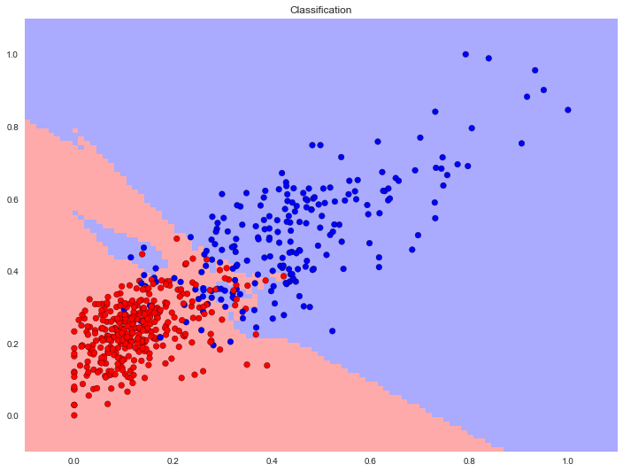

```python
decision_boundary(knn_clf,X,xx,yy,'concpoints.mean','perimeter.mean',y)
```

```python
yhat = knn_clf.predict(X)
accuracy_score(yhat,y)
```

```
0.9384885764499121
```

From the above plot we observe that kNN with 4 neigbors does a decent job in classifying the tumor as malignant(blue) or benign(red) with an accuracy of 94%. However it does capture some noise and overfits the data.

```python
# considering another set of features - radius.mean and area.mean

X = scaled_df[['radius.mean','area.mean']]
knn_clf = KNeighborsClassifier(n_neighbors=4).fit(X,y)
```

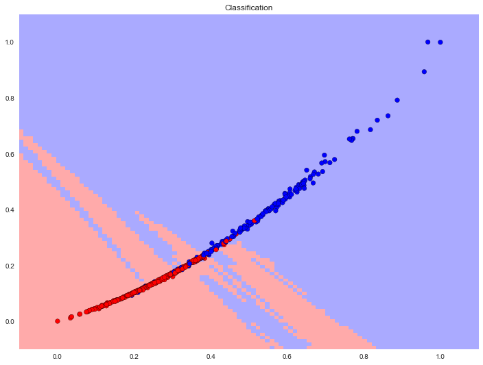

```python
xx,yy = decision_region(X,'radius.mean','area.mean')
decision_boundary(knn_clf,X,xx,yy,'radius.mean','area.mean',y)
```

```python
yhat = knn_clf.predict(X)
accuracy_score(yhat,y)
```

```
0.8927943760984183
```

We can observe that the boundary is not well defined for these set of features

### 2.2 Logistic Case

```python
# considering the same features - radius.mean, area.mean
log_clf = LogisticRegression().fit(X,y)     # training the model
```

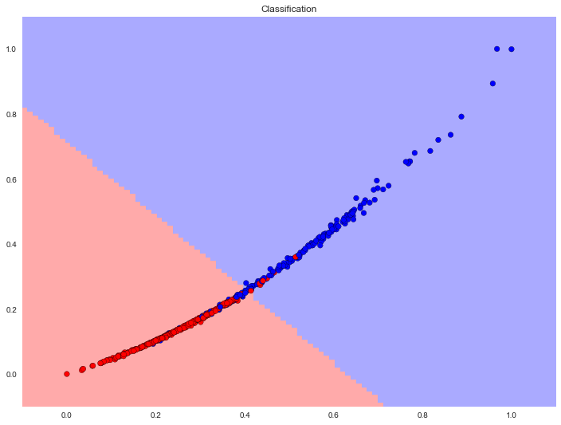

```python
# decision regions or grids remain the same
decision_boundary(log_clf,X,xx,yy,'radius.mean','area.mean',y)
```

```python
# Fitting logistic model
yhat = log_clf.predict(X)
accuracy_score(yhat,y)
```

```
0.8734622144112478
```

```python
# considering another set of features - concpoints.mean, perimeter.mean

X = scaled_df[['concpoints.mean','perimeter.mean']]
log_clf = LogisticRegression().fit(X,y)
```

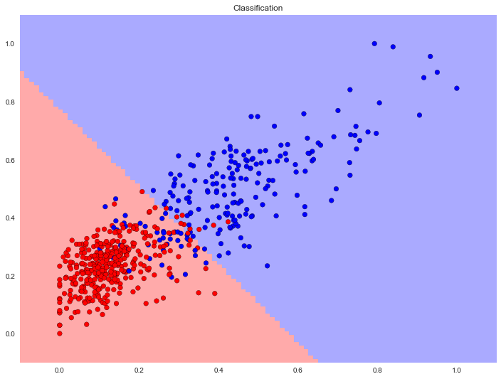

```python
# Plotting decision boundary
xx,yy = decision_region(X,'concpoints.mean','perimeter.mean')
decision_boundary(log_clf,X,xx,yy,'concpoints.mean','perimeter.mean',y)
```

```python
# Prediction and accuracy
yhat = log_clf.predict(X)
accuracy_score(yhat,y)
```

```
0.9103690685413005
```

We can observe from the above two plots that noise is reduced with the logistic model. However accuracy is compensated in this case.

### 2.3 Feature Engineering

```python
# Continuing the same features
# X = scaled_df[['concpoints.mean','perimeter.mean']]
```

```python
# Creating engineered features
X['conc_sq'] = np.square(X['concpoints.mean'])
X['peri_sq'] = np.square(X['perimeter.mean'])
X['conc_log'] = np.log(X['concpoints.mean'])
X['peri_sqrt'] = np.sqrt(X['perimeter.mean'])
X['conc_peri'] = np.multiply(X['concpoints.mean'],X['perimeter.mean'])
```

[output not shown]

```python
X.head()
```

|  | concpoints.mean | perimeter.mean | conc_sq | peri_sq | conc_log | peri_sqrt | conc_peri |
| --- | --- | --- | --- | --- | --- | --- | --- |
| 0 | 0.731113 | 0.545989 | 0.534527 | 0.298103 | -0.313187 | 0.738910 | 0.399179 |
| 1 | 0.348757 | 0.615783 | 0.121632 | 0.379189 | -1.053379 | 0.784719 | 0.214759 |
| 2 | 0.635686 | 0.595743 | 0.404097 | 0.354910 | -0.453051 | 0.771844 | 0.378706 |
| 3 | 0.522863 | 0.233501 | 0.273386 | 0.054523 | -0.648436 | 0.483220 | 0.122089 |
| 4 | 0.518390 | 0.630986 | 0.268728 | 0.398143 | -0.657028 | 0.794346 | 0.327097 |

```python
# handling calculation warnings in case we get infinity
X[np.isneginf(X['conc_log'])] = 0   # removing infinite values and replacing it with zero
np.isfinite(X).sum()                # test element-wise for finiteness
```

```
concpoints.mean    569
perimeter.mean     569
conc_sq            569
peri_sq            569
conc_log           569
peri_sqrt          569
conc_peri          569
dtype: int64
```

```python
X_engineered = X[['concpoints.mean','perimeter.mean','conc_sq','peri_sq','conc_peri']]
```

```python
# Fitting logistic model on engineered features
engineered_log_clf = LogisticRegression().fit(X_engineered,y)
```

```python
engineered_log_clf
```

```
LogisticRegression(C=1.0, class_weight=None, dual=False, fit_intercept=True,
          intercept_scaling=1, max_iter=100, multi_class='ovr', n_jobs=1,
          penalty='l2', random_state=None, solver='liblinear', tol=0.0001,
          verbose=0, warm_start=False)
```

```python
xxf,yyf = decision_region(X_engineered,'concpoints.mean','perimeter.mean')
```

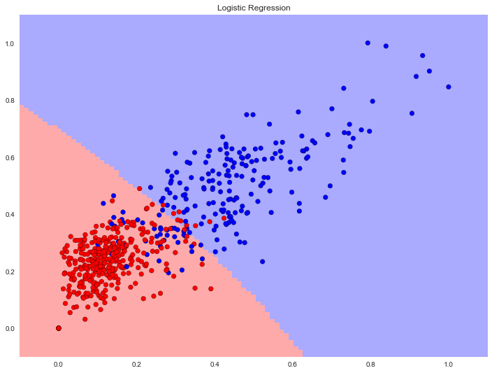

```python
# Plotting decison boundary for engineered features

yhat_engineered = engineered_log_clf.predict(np.c_[xxf.ravel(),yyf.ravel(),(xxf*xxf).ravel(),(yyf*yyf).ravel(),(xxf*yyf).ravel()])
yhat_engineered = yhat_engineered.reshape(xxf.shape)

cmap_light = ListedColormap(['#FFAAAA','#AAFFAA','#AAAAFF'])
cmap_bold = ListedColormap(['#FF0000','#00FF00','#0000FF'])
plt.figure(figsize=(12,9))
plt.pcolormesh(xx,yy,yhat_engineered,cmap=cmap_light)

# plot the training points
plt.scatter(X_engineered.values[:,0],X_engineered.values[:,1],c=y, cmap=cmap_bold,edgecolor='k', s=45)
plt.xlim(xxf.min(),xxf.max())
plt.ylim(yyf.min(),yyf.max())
plt.title("Logistic Regression")
plt.show()
```

```python
yhat = engineered_log_clf.predict(X_engineered)
accuracy_score(yhat,y)
```

```
0.9103690685413005
```

By adding new engineered features the variance is increased which could be observed by the slight bend in the decision boundary.

### Using full data

##### 3.1 k-fold Cross Validation

```python
# Function that takes in a dataset and performs nfolds k fold cross validation
# where k = number of folds
def kFolds_CV(k,data,targetVariable):

    indices = np.arange(len(data))
    np.random.shuffle(indices)

    # creating/initializing empty containers for storing the values
    results = []
    accuracy =[]
    precision = []
    recall = []


    for i in range(k):
        itest = indices[i::k]  # go by k
        itrain = list(set(indices).difference(itest))
        testDat = data.iloc[itest]
        trainDat = data.iloc[itrain]
        #ytestDat = ylog_train.iloc[itest]
        #ytrainDat = ylog_train.iloc[itrain]

        Xkf_train = trainDat[trainDat.columns.difference([targetVariable])]    # removing the target variable from training set
        Xkf_test = testDat[testDat.columns.difference([targetVariable])]       # removing the target variable from test set
        ykf_train = trainDat[targetVariable]
        ykf_test = testDat[targetVariable]

        logkf_clf = LogisticRegression(C=1).fit(Xkf_train,ykf_train)           # Fitting logistic regression model
        y_predkf = logkf_clf.predict(Xkf_test)

        acc = metrics.accuracy_score(ykf_test, y_predkf)                       # Calculating metrics for each fold
        prec = metrics.precision_score(ykf_test,y_predkf)
        rec = metrics.recall_score(ykf_test,y_predkf)

        accuracy.append(acc)                                                   # appending the results of each fold to the main list
        precision.append(prec)
        recall.append(recall)


        print("\n Accuracy Kfold %i :" %(i), acc),  print("Precision Kfold %i :" %(i), prec),  print("Recall Kfold %i :" %(i), rec)

    print("\n Mean Accuracy: ",np.mean(accuracy))
    #results.append(np.mean(accuracy))
    #results.append(np.mean(precision))
    #results.append(np.mean(recall))
    #return results
```

```python
kFolds_CV(10,df,'diagnosis')
```

```
 Accuracy Kfold 0 : 0.9473684210526315
Precision Kfold 0 : 0.967741935483871
Recall Kfold 0 : 0.9375

 Accuracy Kfold 1 : 0.9649122807017544
Precision Kfold 1 : 1.0
Recall Kfold 1 : 0.8461538461538461

 Accuracy Kfold 2 : 0.9824561403508771
Precision Kfold 2 : 0.9523809523809523
Recall Kfold 2 : 1.0

 Accuracy Kfold 3 : 0.9649122807017544
Precision Kfold 3 : 1.0
Recall Kfold 3 : 0.9285714285714286

 Accuracy Kfold 4 : 0.9824561403508771
Precision Kfold 4 : 1.0
Recall Kfold 4 : 0.9285714285714286

 Accuracy Kfold 5 : 0.8596491228070176
Precision Kfold 5 : 0.9090909090909091
Recall Kfold 5 : 0.7692307692307693

 Accuracy Kfold 6 : 0.9649122807017544
Precision Kfold 6 : 1.0
Recall Kfold 6 : 0.9090909090909091

 Accuracy Kfold 7 : 0.9473684210526315
Precision Kfold 7 : 0.8333333333333334
Recall Kfold 7 : 1.0

 Accuracy Kfold 8 : 0.9473684210526315
Precision Kfold 8 : 0.85
Recall Kfold 8 : 1.0

 Accuracy Kfold 9 : 0.9464285714285714
Precision Kfold 9 : 0.9583333333333334
Recall Kfold 9 : 0.92

 Mean Accuracy:  0.9507832080200501
```

```python
kFolds_CV(10,df,'diagnosis')
```

```
 Accuracy Kfold 0 : 0.9473684210526315
Precision Kfold 0 : 0.9166666666666666
Recall Kfold 0 : 0.9565217391304348

 Accuracy Kfold 1 : 0.9473684210526315
Precision Kfold 1 : 0.9444444444444444
Recall Kfold 1 : 0.8947368421052632

 Accuracy Kfold 2 : 0.9649122807017544
Precision Kfold 2 : 0.9583333333333334
Recall Kfold 2 : 0.9583333333333334

 Accuracy Kfold 3 : 0.9473684210526315
Precision Kfold 3 : 0.9444444444444444
Recall Kfold 3 : 0.8947368421052632

 Accuracy Kfold 4 : 0.9649122807017544
Precision Kfold 4 : 1.0
Recall Kfold 4 : 0.92

 Accuracy Kfold 5 : 0.9649122807017544
Precision Kfold 5 : 1.0
Recall Kfold 5 : 0.8947368421052632

 Accuracy Kfold 6 : 1.0
Precision Kfold 6 : 1.0
Recall Kfold 6 : 1.0

 Accuracy Kfold 7 : 0.9473684210526315
Precision Kfold 7 : 0.95
Recall Kfold 7 : 0.9047619047619048

 Accuracy Kfold 8 : 0.9298245614035088
Precision Kfold 8 : 0.8888888888888888
Recall Kfold 8 : 0.8888888888888888

 Accuracy Kfold 9 : 0.8928571428571429
Precision Kfold 9 : 0.8571428571428571
Recall Kfold 9 : 0.8571428571428571

 Mean Accuracy:  0.950689223057644
```

### 3.2 Regularization

```python
#
```

```python
def kFolds_CV_Reg(k,data,targetVariable,lam):

    indices = np.arange(len(data))
    np.random.shuffle(indices)

    results = []
    accuracy =[]
    precision = []
    recall = []


    for i in range(k):
        itest = indices[i::k]  # go by k
        itrain = list(set(indices).difference(itest))
        testDat = data.iloc[itest]
        trainDat = data.iloc[itrain]
        #ytestDat = ylog_train.iloc[itest]
        #ytrainDat = ylog_train.iloc[itrain]

        Xkf_train = trainDat[trainDat.columns.difference([targetVariable])]      # removing the target variable from training set
        Xkf_test = testDat[testDat.columns.difference([targetVariable])]         # removing the target variable from test set
        ykf_train = trainDat[targetVariable]
        ykf_test = testDat[targetVariable]

        # we can tune the value of lambda ; i.e. control the amount of regularization
        logkf_clf = LogisticRegression(C=1/lam).fit(Xkf_train,ykf_train)        # Fitting logistic regression model with
        y_predkf = logkf_clf.predict(Xkf_test)                                  # Using ridge regularization as penalty='l2', by default

        acc = metrics.accuracy_score(ykf_test, y_predkf)
        prec = metrics.precision_score(ykf_test,y_predkf)
        rec = metrics.recall_score(ykf_test,y_predkf)

        accuracy.append(acc)
        precision.append(prec)
        recall.append(recall)


        #print("\n Accuracy Kfold %i :" %(i), acc),  print("Precision Kfold %i :" %(i), prec),  print("Recall Kfold %i :" %(i), rec)

    results.append(np.mean(accuracy))
    results.append(lam)
    return results
```

```python
lambda_vals = np.logspace(-5,5,20)
lambda_vals
```

```
array([1.00000000e-05, 3.35981829e-05, 1.12883789e-04, 3.79269019e-04,
       1.27427499e-03, 4.28133240e-03, 1.43844989e-02, 4.83293024e-02,
       1.62377674e-01, 5.45559478e-01, 1.83298071e+00, 6.15848211e+00,
       2.06913808e+01, 6.95192796e+01, 2.33572147e+02, 7.84759970e+02,
       2.63665090e+03, 8.85866790e+03, 2.97635144e+04, 1.00000000e+05])
```

```python
ridge_regularization = []

for value in lambda_vals:
    ridge_regularization.append(kFolds_CV_Reg(10,scaled_df,'diagnosis',lam=value))
```

```python
ridge_regularization_df = pd.DataFrame(ridge_regularization, columns = ['accuracy_score','lambda'])
ridge_regularization_df
```

|  | accuracy_score | lambda |
| --- | --- | --- |
| 0 | 0.959461 | 0.000010 |
| 1 | 0.957832 | 0.000034 |
| 2 | 0.959586 | 0.000113 |
| 3 | 0.961341 | 0.000379 |
| 4 | 0.966573 | 0.001274 |
| 5 | 0.970144 | 0.004281 |
| 6 | 0.971867 | 0.014384 |
| 7 | 0.975407 | 0.048329 |
| 8 | 0.971867 | 0.162378 |
| 9 | 0.966635 | 0.545559 |
| 10 | 0.954323 | 1.832981 |
| 11 | 0.936654 | 6.158482 |
| 12 | 0.919173 | 20.691381 |
| 13 | 0.887625 | 69.519280 |
| 14 | 0.820833 | 233.572147 |
| 15 | 0.720645 | 784.759970 |
| 16 | 0.664317 | 2636.650899 |
| 17 | 0.665977 | 8858.667904 |
| 18 | 0.657331 | 29763.514416 |
| 19 | 0.655294 | 100000.000000 |

```python
ridge_regularization_df.loc[ridge_regularization_df['accuracy_score'].idxmax()]
```

```
accuracy_score    0.975407
lambda            0.048329
Name: 7, dtype: float64
```

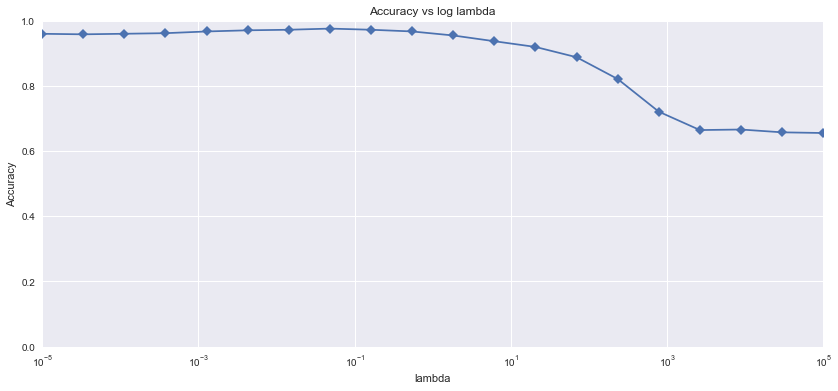

```python
# Accuracy as a function of lambda
plt.figure(figsize=(14,6))
plt.plot(ridge_regularization_df['lambda'],ridge_regularization_df['accuracy_score'], marker ="D" )
plt.ylim([0,1])
plt.xlim([0.000010,100000])
plt.xscale('log')
plt.xlabel('lambda')
plt.ylabel('Accuracy')
plt.title('Accuracy vs log lambda')
plt.show()
```

Comparing kNN, Naive Bayes and logistic regression estimators

```python
# splitting data into training and testing sets
X = df.drop('diagnosis', axis = 1)
y = df['diagnosis']

X_train, X_test, y_train, y_test = train_test_split(X,y,test_size = 0.33, random_state = 0)
```

```python
from sklearn.naive_bayes import GaussianNB
```

```python
log_clf = LogisticRegression(C=1000)
knn_clf1= KNeighborsClassifier(n_neighbors=1)
knn_clf5 = KNeighborsClassifier(n_neighbors=5)
knn_clf25 = KNeighborsClassifier(n_neighbors=25)
naiveBayes_clf = GaussianNB()
```

```python
classifiers = [log_clf,knn_clf1,knn_clf5,knn_clf25,naiveBayes_clf]
```

[figure not shown]

```python
plt.figure(figsize=(14,5))
for classifier in classifiers:
    classifier.fit(X_train,y_train)
    yhat = classifier.predict_proba(X_test)[:,1]
    threshold = np.linspace(0,1,20)
    #false_pos = np.empty((20,1))
    #true_pos = np.empty_like(false_pos)
    false_pos = []
    true_pos = []

    for value in threshold:
        #print(index,threshold)
        #true_pos[index] = np.sum(np.logical_and(y_test == 1, (yhat >= threshold) == True))/np.sum(y_test)    # 20 x 1
        #false_pos[index] = np.sum(np.logical_and(y_test ==1, (yhat >= threshold) == True))/np.sum(y_test==0) # 20 x 1
        true_positive = np.sum(np.logical_and(y_test == 1, (yhat >= value) == True))/np.sum(y_test)    # 20 x 1
        false_positive = np.sum(np.logical_and(y_test ==1, (yhat >= value) == True))/np.sum(y_test==0) # 20 x 1
        true_pos.append(true_positive)
        false_pos.append(false_positive)
        #print((false_pos))  # length 2  ; 20x1 shape
    #print(list(false_pos))            #lenght 2  ; 20x1 shape   : 5 20x1 values
    #np.array(false_pos).tolist()
    #np.array(true_pos).tolist()
    plt.plot(false_pos,true_pos)
plt.plot([0, 1], [0, 1], color='navy', linestyle='--')

plt.xlim([-0.01, 1.0])
plt.ylim([0.0, 1.05])
plt.xlabel('False Positive Rate')
plt.ylabel('True Positive Rate')
plt.title('Receiver Operating Characteristic')
plt.legend(labels=['Logistic Regression','Naive Bayes','KNN with K=1','KNN with K=5','KNN with K=25'])
plt.show()
```

```python
# In progress; making some modifications
```